# Project Proposal

# 1. Background and Problem Statement

The project topic will be based on [VAST Challenge 2025](https://vast-challenge.github.io/2025/index.html). We have chosen [Mini-Challenge 1](https://vast-challenge.github.io/2025/MC1.html).

VAST Challenge 2025 Mini Challenge 1 centres on the rise of Sailor Shift, a musician from the island nation of Oceanus. She’s famous for spreading the influence of the Oceanus Folk genre and frequently collaborating with lesser-known artists.

Silas Reed, a local journalist, has assembled a knowledge graph (MC1_graph.json) encompassing artists, albums, songs, collaborations, and influence relationships spanning decades. The result is a directed multigraph of 17,412 nodes and 37,857 edges spanning five node types and twelve relationship types.

The challenge presents a rich but complex network dataset for us to uncover the structural patterns in how Sailor rose to fame, who she influenced, and how Oceanus Folk spread globally. Our project thus aims to build an interactive visual analytics dashboard that helps users trace Sailor Shift’s career, understand how Oceanus Folk spread and evolved, and identify the next likely breakout artists in the genre.

# 2. Project Objectives

Our project is structured around three thematic clusters that map directly to the challenge tasks. We aim to explore and understand:

1. **Sailor Shift’s Career Profile**
   - Who has she been most **influenced** by over time?
   - Who has she **collaborated** with and directly or indirectly influenced?
   - How has she influenced collaborators of the broader **Oceanus Folk community**?
2. **Spread of Oceanus Folk Genre**
   - Was this influence **intermittent** or did it have a **gradual rise**?
   - What **genres** and **top artists** have been most influenced by Oceanus Folk?
   - On the converse, how has Oceanus Folk **changed** with the rise of Sailor Shift? From which genres does it draw most of its **contemporary inspiration**?
3. **Prediction and Profile of Rising Stars**
   - Visualize the careers of three artists. Compare and contrast their **rise in popularity and influence**.
   - Using this characterization, give three **predictions** of who the next Oceanus Folk stars with be over the next five years.

# 3. Dataset Overview

The network json has been converted into a workable **CSV file (mc1_nodes.csv and mc1_edges.csv)** by Prof Kam.

This final graph contains nodes representing persons, songs, albums, musical groups, and record labels, as well as edges representing performance, authorship, group membership, label relationships, and multiple forms of musical influence.

From this graph, we will derive a set of analysis-ready tables for Tableau. These include per-node-type tables, collaboration edges, unified influence edges, artist-level metrics, and precomputed network coordinates for visual layout. Additional derived tables will be created for indirect influence paths, community reach, and rising-star feature engineering.

## 3.1 Node Types

| Node Type | Description | Attributes |
| --- | --- | --- |
| Person | Anyone in the music industry, including singers, producers, instrumentalists, composers, etc | name, stage_name (optional) |
| MusicalGroup | Bands, quartets, small choirs, or other officially organized entities formed by musicians to make music | name |
| RecordLabel | Organizations—professional, commercial, or otherwise institutional—involved in the recording, production, or distribution of the music. | name |
| Song | Information on songs | genre, release_date, notable (bool), notoriety_date (optional), single (optional), written_date (optional) |
| Album | Information on albums | genre, release_date, notable (bool), notoriety_date (optional), written_date (optional) |

**Note on sparse columns:** Attributes like single, genre, and release_date are only defined on Song and Album nodes. When all five node types are loaded into a single DataFrame, these columns appear “NA” for Person, MusicalGroup, and RecordLabel rows. This is expected.

## 3.2 Edge Types

| Edge Type | Description |
| --- | --- |
| PerformerOf | Indicates a that the source node (Person or MusicalGroup) performed the destination node (Song or Album) |
| ComposerOf | Indicates that the source node (Person) composed the destination node (Song or Album) |
| ProducerOf | Indicates that the source node (Person or RecordLabel) participated in the production of the destination node’s work (Song, Album, Person, or MusicalGroup) |
| LyricistOf | Indicates that the source node (Person) wrote lyrics for the destination node (Song or Album) |
| RecordedBy | Indicates that the destination node (RecordLabel) aided in the recording process for the source node (Song or Album) |
| DistributedBy | Indicates that the destination node (RecordLabel) aided in the distribution process for the source node (Song or Album) |
| InStyleOf | Indicates that the source node (Song or Album) was performed at least partly in the style of the destination node (Song, Album, Person, or MusicalGroup) |
| InterpolatesFrom | Indicates that the source node (Song or Album) interpolated a melody from the destination node (Song or Album). |
| CoverOf | Indicates that the source node (Song or Album) is a [cover](https://en.wikipedia.org/wiki/Cover_version) of the destination node (Song or Album) |
| LyricalReferenceTo | Indicates that the source node (Song or Album) makes a lyrical reference to the destination node (Song or Album) |
| DirectlySamples | Indicates that the source node (Song or Album) consists of (an) audio recording(s) that directly reuse a portion of the audio recording of the destination node (Song or Album) via sampling |
| MemberOf | Indicates that the source node (Person) is (or was) a member of the destination node (MusicalGroup) |

**Note on “Influence”:** In this project, ‘Influence’ will refer to any direct or indirect relationship where a source node incorporates elements from a destination node through stylistic (InStyleOf), musical (InterpolatesFrom), lyrical (LyricalReferenceTo), audio-sampling (DirectlySamples). A cover (CoverOf) will also be treated as a form of influence, where the source work is a reinterpretation of the destination work.

# 4. Proposed Methodology

The project will be completed in two main stages. First, Gephi will be used to explore the data, extract relevant nodes for deeper analysis, and generate network coordinates for node-link visualisations that cannot be natively laid out in Tableau. Second, Tableau will be used to build coordinated interactive dashboards that support filtering, comparison, and guided storytelling across all three challenge themes. We will also explore if we can transform the data manually to create Tableau-ready data inputs.

## 4.1 Scope of Work

**Theme 1: Sailor Shift Career Profile**

We will develop dashboards reconstructing Sailor Shift’s artistic trajectory through time, emphasising incoming influences, collaborator relationships, and downstream impact on the Oceanus Folk community. This will require deriving Sailor-linked works, collaborator networks, and direct and indirect influence pathways.

**Theme 2: Spread of Oceanus Folk Genre**

We will analyse how Oceanus Folk propagated through the graph by tracing influence edges, genre transitions, and prominent artists associated with the genre, identifying whether the spread of Oceanus Folk was steady or episodic, and which external genres now shape its contemporary form.

**Theme 3: Prediction and Profile of Rising Stars**

We will build an artist comparison and prediction component that identifies emerging Oceanus Folk artists based on structural and temporal indicators such as collaboration breadth, influence growth, and genre reach, visualising what a rising-star trajectory looks like in comparison with established artists.

## 4.2 Planned Visualisations

The final Tableau application will consist of several coordinated dashboards.

For Theme 1, we plan a Sailor Shift career dashboard combining a release timeline, incoming influence analysis, and collaborator network.

For Theme 2, we plan dashboards showing genre diffusion, top influenced genres and artists, and changing influence into Oceanus Folk over time.

For Theme 3, we plan an artist comparison dashboard and a rising-star prediction dashboard supported by derived metrics and annotated justifications.

## **4.3 Preliminary Data Exploration**

We have done a initial extraction of Sailor Shift’s network graph in Gephi, which we intend to explore further in order to examine the relationships surrounding her.

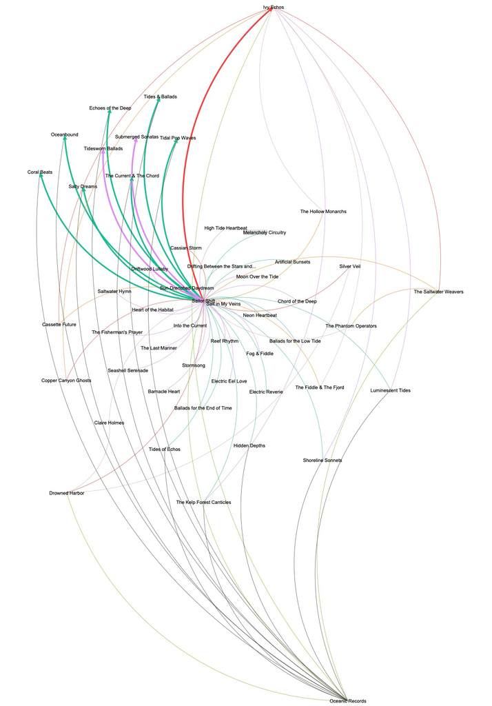

# 5. Project Management

## 5.1 Timeline

Week

Phase

Tasks and Deliverables

10

Data Exploration

- Project Proposal
- Download node and edges CSV and load in Gephi for data exploration
- Data wrangling for Tableau-ready input data

11

Gephi Network Graphs

- Create necessary Gephi graphs
- Explore data in Tableau

12

Dashboard Build

- Build dashboards
- Create Poster

13

Refinement and Insights

- Build dashboards
- Create User Guide
- Finalise Poster

14

Final Presentation

- Poster Presentation
- Submission of Final artifact and project report

## 5.2 Allocation of Work [TBC]

| Team Member | Project Focus |
| --- | --- |
| Marcus Tan | Theme 1 |
| Anthea Chua | Theme 2 |
| Savannah Koh | Theme 3 |

# References

https://vast-challenge.github.io/2025/MC1.html

https://nicole-klassen.medium.com/building-a-network-graph-in-tableau-bdaec20d79e4

https://www.phdata.io/blog/how-to-create-network-visualizations-tableau/